# Southern New Hampshire University

ReMap Experiment: No FAFSA (UG) Dialing + Funding Task

Karen West | k.west2@snhu.edu

Publication Date: 2021-03-24 Updated: 2021-03-24

## Overview

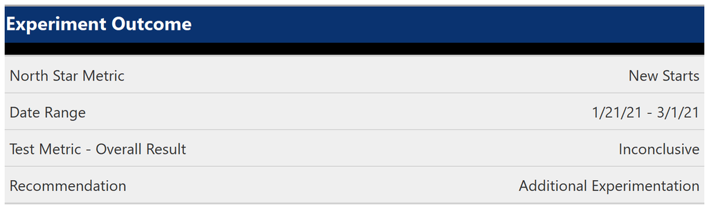

**Theory:** One of the biggest impediments to students who plan on using financial aid is their inability to quickly complete the Free Application for Federal Student Aid (**`FAFSA`**) as part of the admission process. A previous experiment for 21EW3 showed minor improvements in dialer outreach.

**Hypothesis:** Outreaching students who have not completed their **`FAFSA`** *increases* their likelihood to complete their **`FAFSA`**. Adding an additional layer on top of dialing (a funding task) prompting the assigned admission counselor to outreach their student may also *increase* the likelihood that the prospective students will complete their **`FAFSA`**.

## Test Design

**Test Metric:** FAFSA Completion Rate, calculated as:
$$FAFSA Completion Rate = \sum_{n=FAFSA Complete} / \sum_{n=Total Eligible to Complete FAFSA}$$

**Original Testing Groups:** Of all eligible members of the population (full criteria list below), control and experiment groups were assigned according to testing cells on the Unify contact.

- Control Group: **30%** of eligible list would not be dialed nor provided with a funding task
- Dialer Experiment Group: **35%** of eligible list - these were meant to be *dialed only*
- Dialer + Task Experiment Group: **35%** of eligible list - these were meant to be *dialed* and have a *funding task* added in Unify

Dialer and Funding Task treatment dates can be seen in the appendix.  
**Treatments:**

- Dialer: Student added to automated dialer campaign. Task created in Unify to let Admissions Counselor know that student is part of the dialer campaign.
- Funding Task: Task is created in Unify to prompt the Admissions Counselor to contact student to make sure their funding is in place.

### Funding Task Alert

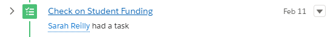

### Funding Task Contents

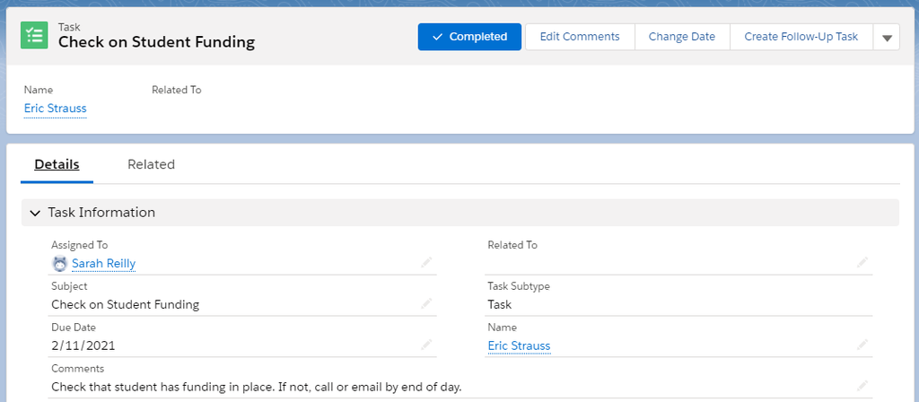

### Dialer Task Alerts

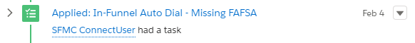

### Dialer Task Contents

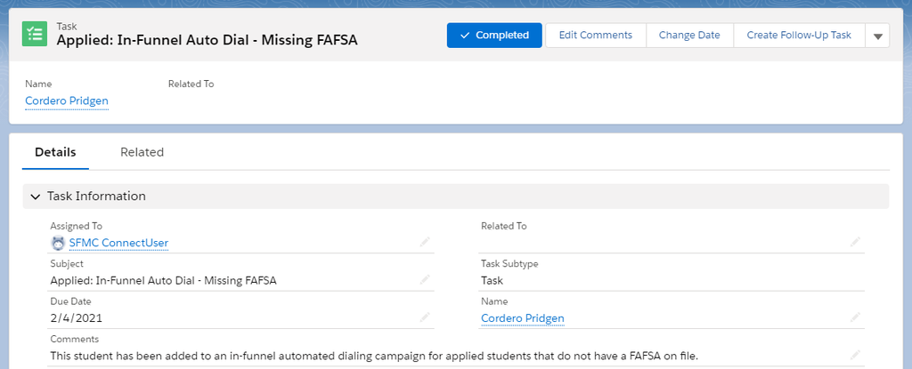

**Reassigned Test and Control Groups:** Test and Control groups were reassigned after the experiment ended based the timing of treatments and population eligibility (more detail provided in the Learnings section). Below is the method of reassigning to the new groups:

- Dialer + Funding Task Group: Originally assigned to the Dialer + Task group and actually received at least one dialer and one funding task.
- Dialer Only Group: Originally assigned to either the Dialer Only or the Dialer + Task group and received a dialer but did not receive any funding task.
- Funding Task Only Group: Originally assigned to the Dialer + Task group and received a funding task but did not receive any dialers.

Corresponding control groups were then matched up to the test groups based on which treatments they *would* have received based on their timing in the eligible population and if they were a part of a test group.

**Experiment Population Eligibility (AKA InPopulation):**

- UG prospective student with open Admission opportunity for the 21EW4 term
- In Applied, App In Progress or Accepted Stage
- Has not completed a 20/21 FAFSA or has only completed the “wrong” FAFSA year (only completed 21/22 FAFSA form and must complete 20/21)
- Prospective student has either indicated they plan on using financial aid (per Financial Plan field in Unify Admission Opportunity), or Financial Plan field is blank
- Is not Course-Work Only (CWO) or a Guild student

## Outcomes & Learnings

### Experiment Results

*NOTE:* Experiment results below are shown based on the “reassigned” test groups explained in the ‘Learnings’ section that follows.

- **Overall Results as of 3/24/21:**
  - FAFSA Completion Rate for the **Dialer + Funding Task** test group was **0.1 percentage points lower (-0.4% change)**. This difference is not statistically significant at 95% confidence.
  - FAFSA Completion Rate for the **Dialer Only** test group was **11.1 percentage points lower (-24.3% change)**. This difference is statistically significant at 95% confidence, however there is a significant sample ratio mismatch in the distribution (more explanation on this in learnings).
  - FAFSA Completion Rate for the **Funding Task Only** test group was **3.3 percentage points higher (+14.9% change)**. This difference is not statistically significant at 95% confidence.

  See appendix for more detail on how to interpret the results.

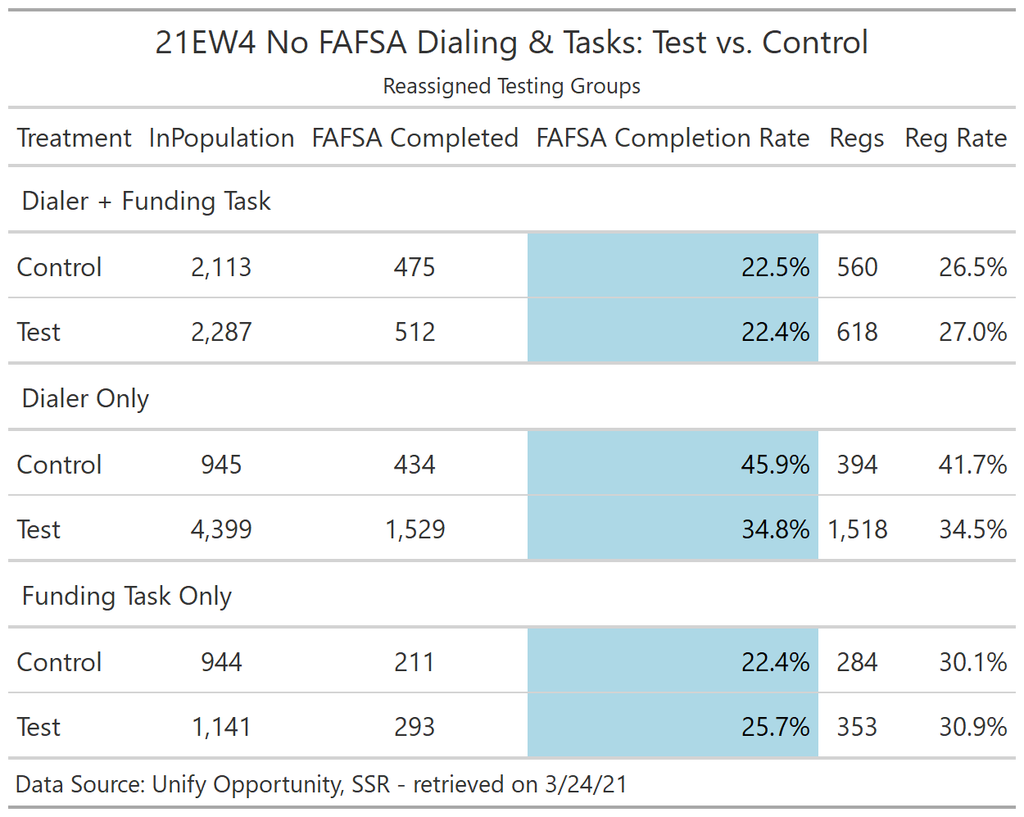

### Learnings

**Treatment/Test Group Discrepancies**  
The major learnings in this experiment are related to test design. The results above are based on having been assigned to an experiment population *and* receiving the intended treatment. The act of assigning an individual to the original test population occurred when the list of applicants were pulled for the dialing and/or funding tasks that were occurring that day; those lists were pulled once per week. Since each type of treatment only occurred every other week, an applicant could be assigned to the “Dialer + Task” group, received the dialer, but fell out of the test population before the funding task occurred. Common reasons for falling out of the population is completion of FAFSA, opportunity being closed/lost or a planned term start change.

The chart below shows the experiment results if we only considered the original test population groups and not the treatments that they actually received.

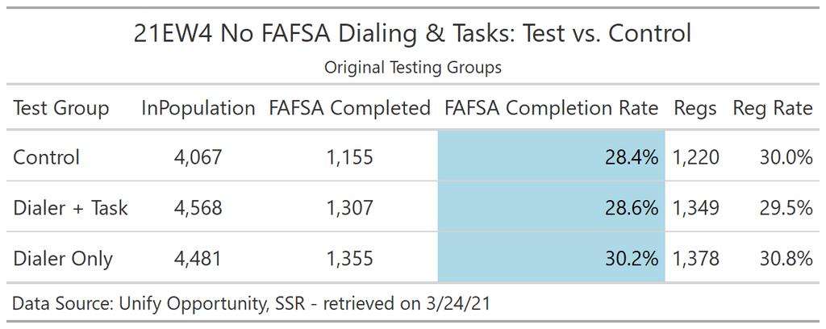

**Test Group Reassignments**  
Because of the misalignment of test population assignments and treatments, individuals were reassigned to specific test and control populations after the conclusion of the experiment to provide a more apples-to-apples comparison of test groups that actually received a treatment and control groups that did not receive the treatment, but were in the population during specific times that would have allowed for them to receive the treatment had we assigned them to a test population originally. **This also means that any metric could be skewed because of this, since relevant factors that could contribute to the likelihood of an event happening (like completing the FAFSA or registering) may no longer be equally spread across groups like they would have been prior to the reassignment.**

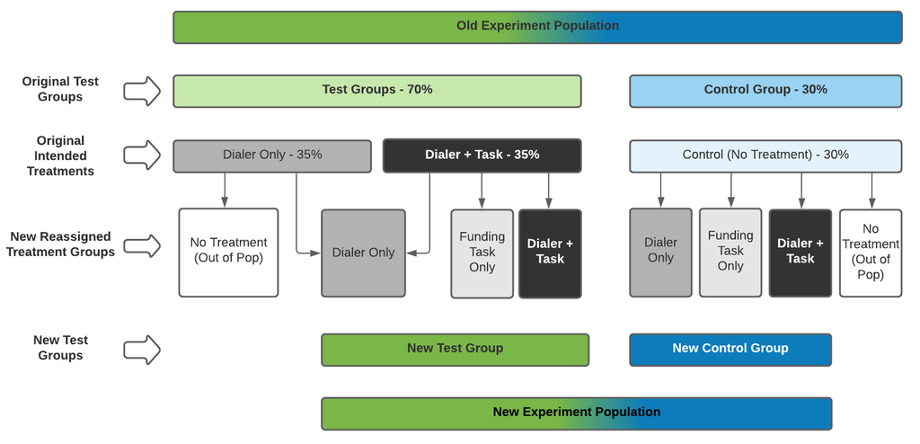

## Glossary of Terms

**`FAFSA`** Free Application for Federal Student Aid

## Appendix

**Melt Rate:** Sample sizes are too small to make any statistically significant conclusions about melt rate. Additionally, as mentioned before, since results were measured from the perspective of the reassigned pools, there is far less certainty that relevant factors across prospective students (lead type, etc.) are equivalent like they would have been in the original randomized test group assignment, meaning that any metric (including melt) could be skewed because of this.

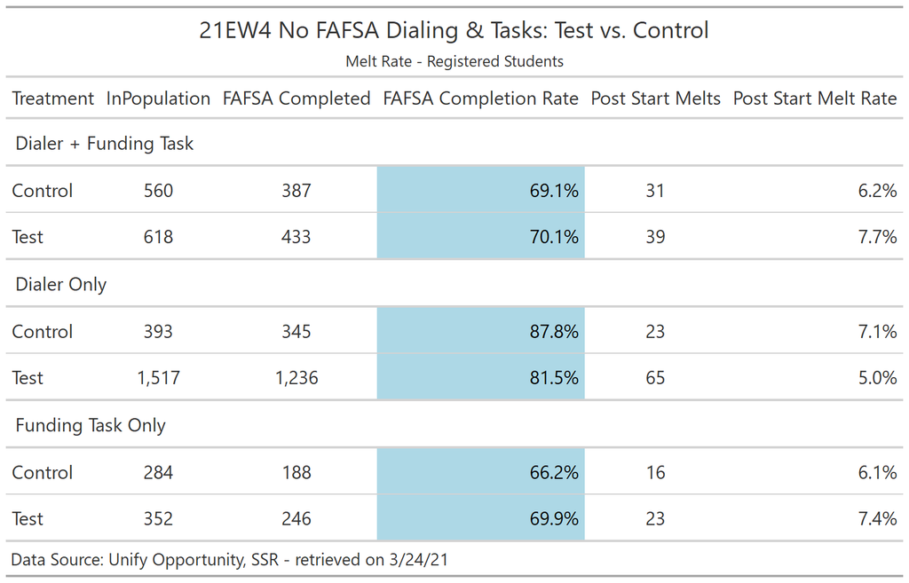

### Treatment Dates

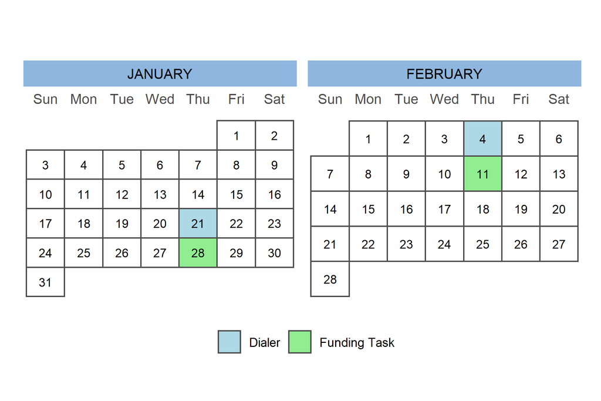

**Note:** Dialer was intended to run again on 2/18 but Data Warehouse issues prevented the list from being generated that day.

**Interpreting the Results**

- **Confidence Level:** The percentage of confidence that the result is a consequence of the change made or treatment administered and not a result of random chance. A 95% confidence interval indicates that we are 95% confident the test result is not due to random chance.
- **Statistical Significance:** A test result is said to be “statistically significant” when the difference between the results of the test and control groups is too big to have been a result of chance.
- **One-Sided vs. Two-Sided Test** A one sided test is used when we only want to prove that the *increase* in conversions (i.e. the metric) that occurred for the test group is significant; it does not consider whether any *decrease* in conversions is significant. A two-sided test evaluates the significance of the test group conversions being higher *or* lower as compared to the control. If we want to be certain that a treatment being tested does not have a negative impact on the metric, then a two-sided test should be conducted.